# numpy get started

## 二、ndarray的属性

4个必记参数： ndim：维度 shape：形状（各维度的长度） size：总长度

dtype：元素类型

```python
data.ndim
```

```
3
```

```python
data.shape
```

```
(100, 100, 3)
```

```python
data.size
```

```
30000
```

```python
data.dtype
```

```
dtype('float64')
```

## 三、ndarray的基本操作

### 1. 索引

一维与列表完全一致 多维时同理

```python
import numpy as np
```

```python
arr1 = np.random.randint(0,100,size=10)
```

```python
arr1
```

```
array([36, 81, 31, 59, 10, 56, 48, 36, 82, 19])
```

```python
arr1[0] = 11
```

```python
arr1
```

```
array([11, 81, 31, 59, 10, 56, 48, 36, 82, 19])
```

```python
arr1[-1]
```

```
19
```

```python
arr1[[0,1,2]]
```

```
array([11, 81, 31])
```

```python
arr2 = np.random.randint(0,100,size=(3,5))
arr2
```

```
array([[46, 36, 77, 67, 25],
       [41, 76, 25, 48, 64],
       [58, 54, 81, 41,  6]])
```

```python
arr2[0][0]
```

```
46
```

```python
arr3 = np.random.randint(0,100,size=(5,5,3))
arr3
```

```
array([[[25, 16, 87],
        [34, 66, 67],
        [71, 84, 45],
        [ 1, 91, 83],
        [60, 79, 93]],

       [[63,  4, 90],
        [ 9, 64, 13],
        [20, 61,  9],
        [66, 60, 35],
        [21, 75,  9]],

       [[ 8, 18, 91],
        [74, 39, 37],
        [ 2, 62, 62],
        [39, 94,  0],
        [15, 59, 34]],

       [[25, 11, 43],
        [17, 46, 64],
        [59, 24, 13],
        [ 9, 15, 42],
        [46, 75, 65]],

       [[82, 52, 89],
        [71, 84, 14],
        [32, 65, 86],
        [ 1, 69, 76],
        [45, 20,  9]]])
```

```python
arr3[0][0][0]
```

```
25
```

### 2. 切片

一维与列表完全一致 多维时同理

```python
arr1
```

```
array([11, 81, 31, 59, 10, 56, 48, 36, 82, 19])
```

```python
arr1[0:3]
```

```
array([11, 81, 31])
```

```python
arr1[::-1]
```

```
array([19, 82, 36, 48, 56, 10, 59, 31, 81, 11])
```

```python
arr1[::2]
```

```
array([11, 31, 10, 48, 82])
```

```python
arr2
```

```
array([[46, 36, 77, 67, 25],
       [41, 76, 25, 48, 64],
       [58, 54, 81, 41,  6]])
```

```python
# 行切片
arr2[0:1]
```

```
array([[46, 36, 77, 67, 25]])
```

```python
# 列切片
arr2[:,0:2]
```

```
array([[46, 36],
       [41, 76],
       [58, 54]])
```

```python
arr2
```

```
array([[46, 36, 77, 67, 25],
       [41, 76, 25, 48, 64],
       [58, 54, 81, 41,  6]])
```

```python
# 需求，将二维数组arr2进行行列逆向变换处理
arr2[::-1,:]
```

```
array([[58, 54, 81, 41,  6],
       [41, 76, 25, 48, 64],
       [46, 36, 77, 67, 25]])
```

```python
arr2[:,::-1]
```

```
array([[25, 67, 77, 36, 46],
       [64, 48, 25, 76, 41],
       [ 6, 41, 81, 54, 58]])
```

```python
import matplotlib.pyplot as plt
%matplotlib inline
```

```python
# 注意：此处超纲，不要紧张
# 读取图片
sister = plt.imread('sister.jpg')
```

```python
sister.shape
```

```
(300, 255, 3)
```

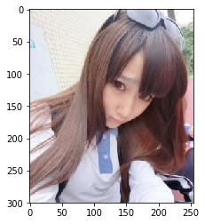

```python
plt.imshow(sister)
```

```python
sister1 = sister[::-1]
```

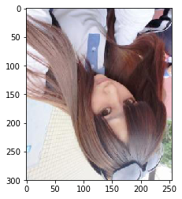

```python
plt.imshow(sister1)
```

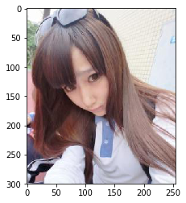

```python
sister2 = sister[:,::-1]
plt.imshow(sister2)
```

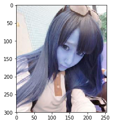

```python
sister3 = sister[:,:,::-1]
plt.imshow(sister3)
```

将数据反转，例如[1,2,3]---->[3,2,1]

两个：：进行切片

### 3. 变形

使用reshape函数，注意参数是一个tuple！

```python
arr5 = np.random.random(size=25)
```

```python
arr5
```

```
array([0.90804528, 0.30869937, 0.74985524, 0.54684972, 0.92053262,
       0.53912835, 0.54695453, 0.84884346, 0.65154233, 0.98041142,
       0.86042376, 0.36942207, 0.78283416, 0.34542292, 0.22834378,
       0.09784852, 0.10707408, 0.00434051, 0.85167701, 0.24166686,
       0.08241626, 0.729516  , 0.07928945, 0.67795173, 0.05147987])
```

```python
arr5.shape
```

```
(25,)
```

```python
arr5.reshape((5,5))
```

```
array([[0.90804528, 0.30869937, 0.74985524, 0.54684972, 0.92053262],
       [0.53912835, 0.54695453, 0.84884346, 0.65154233, 0.98041142],
       [0.86042376, 0.36942207, 0.78283416, 0.34542292, 0.22834378],
       [0.09784852, 0.10707408, 0.00434051, 0.85167701, 0.24166686],
       [0.08241626, 0.729516  , 0.07928945, 0.67795173, 0.05147987]])
```

```python
arr6 = arr5.reshape((25,1))
arr6
```

```
array([[0.90804528],
       [0.30869937],
       [0.74985524],
       [0.54684972],
       [0.92053262],
       [0.53912835],
       [0.54695453],
       [0.84884346],
       [0.65154233],
       [0.98041142],
       [0.86042376],
       [0.36942207],
       [0.78283416],
       [0.34542292],
       [0.22834378],
       [0.09784852],
       [0.10707408],
       [0.00434051],
       [0.85167701],
       [0.24166686],
       [0.08241626],
       [0.729516  ],
       [0.07928945],
       [0.67795173],
       [0.05147987]])
```

```python
display(arr5.shape,arr6.shape)
```

```
(25,)
```

```
(25, 1)
```

-1 表示根据数组大小自动计算行数。

```python
arr7 = arr5.reshape(-1,1)
```

```python
arr7
```

```
array([[0.90804528],
       [0.30869937],
       [0.74985524],
       [0.54684972],
       [0.92053262],
       [0.53912835],
       [0.54695453],
       [0.84884346],
       [0.65154233],
       [0.98041142],
       [0.86042376],
       [0.36942207],
       [0.78283416],
       [0.34542292],
       [0.22834378],
       [0.09784852],
       [0.10707408],
       [0.00434051],
       [0.85167701],
       [0.24166686],
       [0.08241626],
       [0.729516  ],
       [0.07928945],
       [0.67795173],
       [0.05147987]])
```

```python
arr8 = np.random.random(size=(5,5,3))
arr8
```

```
array([[[0.4378124 , 0.86622411, 0.4514025 ],
        [0.20208716, 0.39066363, 0.81880838],
        [0.65304289, 0.70395026, 0.37192004],
        [0.02566805, 0.70963079, 0.04469499],
        [0.69951547, 0.54504744, 0.56235149]],

       [[0.1532418 , 0.0802895 , 0.80770669],
        [0.97583237, 0.18756185, 0.62407815],
        [0.13734561, 0.64034679, 0.07860697],
        [0.47930437, 0.6461185 , 0.25885189],
        [0.77657177, 0.62902119, 0.74812582]],

       [[0.09210895, 0.68729732, 0.87953284],
        [0.1213739 , 0.67701726, 0.87934454],
        [0.71747162, 0.3977164 , 0.75665751],
        [0.81382573, 0.31601279, 0.49267272],
        [0.96546174, 0.63272018, 0.26494927]],

       [[0.6404596 , 0.82405862, 0.41854037],
        [0.54052876, 0.28731239, 0.07270707],
        [0.09100632, 0.81935162, 0.13356481],
        [0.18376116, 0.80592834, 0.11226161],
        [0.84632946, 0.44263834, 0.97578643]],

       [[0.37315097, 0.75616857, 0.90959226],
        [0.5913203 , 0.40505837, 0.31871155],
        [0.09215261, 0.35348856, 0.29660107],
        [0.18349724, 0.18251386, 0.34683597],
        [0.29426166, 0.96583895, 0.08173155]]])
```

```python
# 变成一列
arr8.reshape(-1,1)
```

```
array([[0.4378124 ],
       [0.86622411],
       [0.4514025 ],
       [0.20208716],
       [0.39066363],
       [0.81880838],
       [0.65304289],
       [0.70395026],
       [0.37192004],
       [0.02566805],
       [0.70963079],
       [0.04469499],
       [0.69951547],
       [0.54504744],
       [0.56235149],
       [0.1532418 ],
       [0.0802895 ],
       [0.80770669],
       [0.97583237],
       [0.18756185],
       [0.62407815],
       [0.13734561],
       [0.64034679],
       [0.07860697],
       [0.47930437],
       [0.6461185 ],
       [0.25885189],
       [0.77657177],
       [0.62902119],
       [0.74812582],
       [0.09210895],
       [0.68729732],
       [0.87953284],
       [0.1213739 ],
       [0.67701726],
       [0.87934454],
       [0.71747162],
       [0.3977164 ],
       [0.75665751],
       [0.81382573],
```

[output cut: 20 more lines]

```
       [0.37315097],
       [0.75616857],
       [0.90959226],
       [0.5913203 ],
       [0.40505837],
       [0.31871155],
       [0.09215261],
       [0.35348856],
       [0.29660107],
       [0.18349724],
       [0.18251386],
       [0.34683597],
       [0.29426166],
       [0.96583895],
       [0.08173155]])
```

```python
# 变成一行
arr8.reshape(1,-1)
```

```
array([[0.4378124 , 0.86622411, 0.4514025 , 0.20208716, 0.39066363,
        0.81880838, 0.65304289, 0.70395026, 0.37192004, 0.02566805,
        0.70963079, 0.04469499, 0.69951547, 0.54504744, 0.56235149,
        0.1532418 , 0.0802895 , 0.80770669, 0.97583237, 0.18756185,
        0.62407815, 0.13734561, 0.64034679, 0.07860697, 0.47930437,
        0.6461185 , 0.25885189, 0.77657177, 0.62902119, 0.74812582,
        0.09210895, 0.68729732, 0.87953284, 0.1213739 , 0.67701726,
        0.87934454, 0.71747162, 0.3977164 , 0.75665751, 0.81382573,
        0.31601279, 0.49267272, 0.96546174, 0.63272018, 0.26494927,
        0.6404596 , 0.82405862, 0.41854037, 0.54052876, 0.28731239,
        0.07270707, 0.09100632, 0.81935162, 0.13356481, 0.18376116,
        0.80592834, 0.11226161, 0.84632946, 0.44263834, 0.97578643,
        0.37315097, 0.75616857, 0.90959226, 0.5913203 , 0.40505837,
        0.31871155, 0.09215261, 0.35348856, 0.29660107, 0.18349724,
        0.18251386, 0.34683597, 0.29426166, 0.96583895, 0.08173155]])
```

### 4. 级联

1. np.concatenate() 级联需要注意的点：
2. 级联的参数是列表：一定要加中括号或小括号
3. 维度必须相同
4. 形状相符
5. 【重点】级联的方向默认是shape这个tuple的第一个值所代表的维度方向
6. 可通过axis参数改变级联的方向

```python
n1 = np.ones(shape=(6,3))
n2 = np.zeros(shape=(6,3))
```

```python
display(n1,n2)
```

```
array([[1., 1., 1.],
       [1., 1., 1.],
       [1., 1., 1.],
       [1., 1., 1.],
       [1., 1., 1.],
       [1., 1., 1.]])
```

```
array([[0., 0., 0.],
       [0., 0., 0.],
       [0., 0., 0.],
       [0., 0., 0.],
       [0., 0., 0.],
       [0., 0., 0.]])
```

```python
np.concatenate?
```

[output not shown]

[output cut: 24 more lines]

[output not shown]

```python
# axis就表示维度的方向
np.concatenate((n1,n2),axis=1)
```

```
array([[1., 1., 1., 0., 0., 0.],
       [1., 1., 1., 0., 0., 0.],
       [1., 1., 1., 0., 0., 0.],
       [1., 1., 1., 0., 0., 0.],
       [1., 1., 1., 0., 0., 0.],
       [1., 1., 1., 0., 0., 0.]])
```

horizontal  
vertical

1. np.hstack与np.vstack  
   水平级联与垂直级联,处理自己，进行维度的变更

```python
np.hstack((n1,n2))
```

```
array([[1., 1., 1., 0., 0., 0.],
       [1., 1., 1., 0., 0., 0.],
       [1., 1., 1., 0., 0., 0.],
       [1., 1., 1., 0., 0., 0.],
       [1., 1., 1., 0., 0., 0.],
       [1., 1., 1., 0., 0., 0.]])
```

```python
np.vstack((n1,n2))
```

```
array([[1., 1., 1.],
       [1., 1., 1.],
       [1., 1., 1.],
       [1., 1., 1.],
       [1., 1., 1.],
       [1., 1., 1.],
       [0., 0., 0.],
       [0., 0., 0.],
       [0., 0., 0.],
       [0., 0., 0.],
       [0., 0., 0.],
       [0., 0., 0.]])
```

### 5. 切分

与级联类似，三个函数完成切分工作：

- np.split
- np.vsplit
- np.hsplit

```python
arr = np.random.randint(0,100,size=(6,6))
arr
```

```
array([[85, 23, 92, 98, 83, 80],
       [42, 82, 77, 19, 91, 82],
       [61, 16, 23, 86,  1, 11],
       [61, 57, 44,  5, 10, 25],
       [24, 93,  0, 27, 35, 25],
       [50, 47, 61, 10, 48, 44]])
```

```python
np.split?
```

[output not shown]

[output cut: 11 more lines]

[output not shown]

在这个例子中，我们定义了一个一维数组 arr 包含整数 1 到 9。通过使用 np.split(arr, indices) 并传递索引数组 indices = [2, 5, 7]，我们将数组 arr 按照索引2、5和7进行分割，生成了四个子数组。然后，我们使用循环打印输出了每个子数组。

```python
import numpy as np

arr10 = np.array([1, 2, 3, 4, 5, 6, 7, 8, 9])
indices = [2, 5, 7]

subarrays = np.split(arr10, indices)

for subarray in subarrays:
    print(subarray)
```

```
[1 2]
[3 4 5]
[6 7]
[8 9]
```

```python
# 指定切分的块数来进行切分，axis控制轴向
np.split(arr,indices_or_sections=3,axis=1)
```

```
[array([[85, 23],
        [42, 82],
        [61, 16],
        [61, 57],
        [24, 93],
        [50, 47]]), array([[92, 98],
        [77, 19],
        [23, 86],
        [44,  5],
        [ 0, 27],
        [61, 10]]), array([[83, 80],
        [91, 82],
        [ 1, 11],
        [10, 25],
        [35, 25],
        [48, 44]])]
```

```python
np.arange(8)
```

```
array([0, 1, 2, 3, 4, 5, 6, 7])
```

```python
# 自定义切分
# n m  切分范围为 0~n ,n~m, m~last
np.split(arr,indices_or_sections=[3,5],axis=1)
```

```
[array([[85, 23, 92],
        [42, 82, 77],
        [61, 16, 23],
        [61, 57, 44],
        [24, 93,  0],
        [50, 47, 61]]), array([[98, 83],
        [19, 91],
        [86,  1],
        [ 5, 10],
        [27, 35],
        [10, 48]]), array([[80],
        [82],
        [11],
        [25],
        [25],
        [44]])]
```

### 6. 副本

所有赋值运算不会为ndarray的任何元素创建副本。对赋值后的对象的操作也对原来的对象生效。

可使用copy()函数创建副本

```python
arr = np.random.randint(0,10,10)
arr
```

```
array([3, 3, 4, 3, 0, 4, 9, 3, 2, 5])
```

```python
arr[0] = 100
```

```python
arr
```

```
array([100,   3,   4,   3,   0,   4,   9,   3,   2,   5])
```

```python
copy_arr = arr.copy()
```

```python
arr[0] = 10
arr
```

```
array([10,  3,  4,  3,  0,  4,  9,  3,  2,  5])
```

```python
copy_arr
```

```
array([100,   3,   4,   3,   0,   4,   9,   3,   2,   5])
```